# Practical Machine Learning - Course Project

MB

December 15, 2014

## Synopsis

Several devices enable collection of information about personal activity, in particular movement. A group of people performed barbell lifts in different manners that are assigned to 5 categories and data is available (please refer to http://groupware.les.inf.puc-rio.br/har).

Here I have investigated which of the monitored movement features can be used to assess if lift was performed correctly or not and a predictor model is setup.

To This aim, the original training set is actually split in a set of data that is used to train the random forest model and a validation set to cross-validate the model and to estimate the model out-of-sample error.

Finally, the model is applied to the test set, for which informationa about the manner each barbell-lift is done is not available and results are submitted to Coursera.

## Downloading and reading data

```r
url_train<-"http://d396qusza40orc.cloudfront.net/predmachlearn/pml-training.csv"
train<-read.csv(file=url_train, na.strings=c("", "NA", "NULL"))
url_test<-"http://d396qusza40orc.cloudfront.net/predmachlearn/pml-testing.csv"
test<-read.csv(file=url_test, na.strings=c("", "NA", "NULL"))
```

## Data pre-processing

### Signals

Columns containing information that is not useful for the present analysis are removed. In particular, all columns with movement signals are retained.

```r
remove<- grep("var_|amplitude_|max_|min_|avg_|stddev_|kurtosis_|skewness_|_timestamp|window|user_name|X", names(train))
train<-train[,-remove]
```

We finally have 52 signal columns and 19622 observations, which include 0 NA values.

### Training and validation sets

The original training is then split in a training set (70%) and a validation set (30%) for cross validation and error estimate. Notice that the test set does not contain ‘classe’ outcome, which describes how the barbell-lift was done, and consequently the original training set has to be partitioned in training and validations sets.

```r
library(caret)
set.seed(1)
inTrain <- createDataPartition(train$classe, p=0.7, list=FALSE)
training <- train[inTrain,]
testing <- train[-inTrain,]
```

## Classification tree

Features that most discriminate among ’classe’s can be dissected by a classification tree.

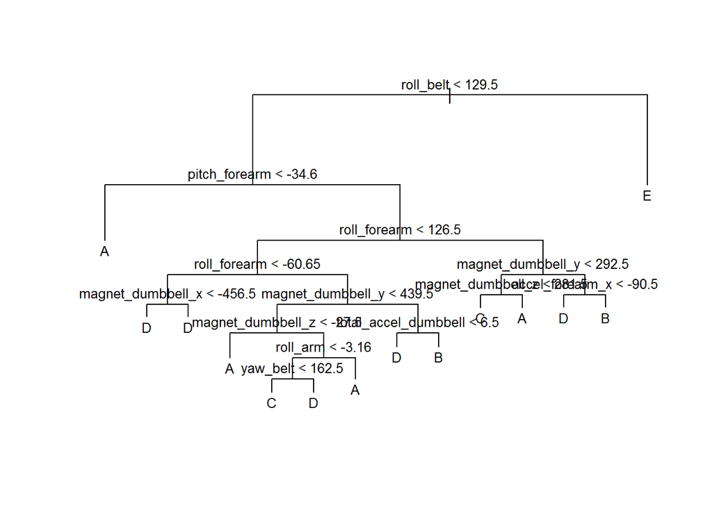

```r
library(tree)
set.seed(1)
mod.tree=tree(classe~.,data=training)
plot(mod.tree)
text(mod.tree, pretty=0, cex =.8)
```

It is not possible to apply single features to predict ‘classe’.

## RandomForest model

Predicting the outcome class ‘classe’ based on the movement signals is a classification problem that can be solved with the random forest decision tree. Here I have calculated a random forest model to predict the ‘classe’ feature (the manner the barbell-lift was done):

```r
library(randomForest)
set.seed(1)
mod.rf<-randomForest(classe~., data=training, importance=TRUE)
print(mod.rf)
```

```
##
## Call:
##  randomForest(formula = classe ~ ., data = training, importance = TRUE)
##                Type of random forest: classification
##                      Number of trees: 500
## No. of variables tried at each split: 7
##
##         OOB estimate of  error rate: 0.52%
## Confusion matrix:
##      A    B    C    D    E class.error
## A 3901    3    0    0    2 0.001280082
## B   12 2641    5    0    0 0.006395786
## C    0   14 2377    5    0 0.007929883
## D    0    0   19 2232    1 0.008880995
## E    0    0    3    7 2515 0.003960396
```

The out-of-bag error rate is about 0.5%.

### Cross-validation on validation set

I am applying now the prediction model to the validation set, for which the real outcome is known, to check performance of the predicting model by comparing predicted outcomes to the corresponding knwon values, and to calculate out-of-sample error.

```r
validation<-predict(mod.rf, testing)
confusionMatrix(testing$classe, validation)
```

```
## Confusion Matrix and Statistics
##
##           Reference
## Prediction    A    B    C    D    E
##          A 1673    0    0    0    1
##          B    1 1136    2    0    0
##          C    0    6 1019    1    0
##          D    0    0    3  959    2
##          E    0    0    0    3 1079
##
## Overall Statistics
##
##                Accuracy : 0.9968
##                  95% CI : (0.995, 0.9981)
##     No Information Rate : 0.2845
##     P-Value [Acc > NIR] : < 2.2e-16
##
##                   Kappa : 0.9959
##  Mcnemar's Test P-Value : NA
##
## Statistics by Class:
##
##                      Class: A Class: B Class: C Class: D Class: E
## Sensitivity            0.9994   0.9947   0.9951   0.9958   0.9972
## Specificity            0.9998   0.9994   0.9986   0.9990   0.9994
## Pos Pred Value         0.9994   0.9974   0.9932   0.9948   0.9972
## Neg Pred Value         0.9998   0.9987   0.9990   0.9992   0.9994
## Prevalence             0.2845   0.1941   0.1740   0.1636   0.1839
## Detection Rate         0.2843   0.1930   0.1732   0.1630   0.1833
## Detection Prevalence   0.2845   0.1935   0.1743   0.1638   0.1839
## Balanced Accuracy      0.9996   0.9971   0.9968   0.9974   0.9983
```

The out-of-sample error rate, calculated from cross-validation, is also low (0.3%) and similar to the out-of-bag error shown in the paragraph above.

## Prediction on test set

Finally, the random forest model is applied to predict ‘classe’ in the test set.

```r
predict(mod.rf, test)
```

```
##  1  2  3  4  5  6  7  8  9 10 11 12 13 14 15 16 17 18 19 20
##  B  A  B  A  A  E  D  B  A  A  B  C  B  A  E  E  A  B  B  B
## Levels: A B C D E
```

These results are submitted to the Coursera website.